# MEDICION DE SEÑALES NO SENOIDALES

## SEÑAL CUADRADA

Hacemos los import de rigor, para graficar, para procesamiento numerico y para generar señales.

```python
import numpy as np
from scipy import signal
import matplotlib.pyplot as plt
```

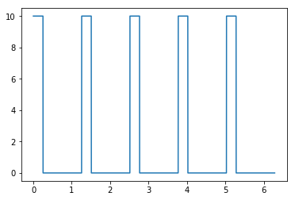

```python
amplitud=5
offset=5
d=0.2
t=np.linspace(0,2*np.pi,10000,endpoint=False) ## de 0 a 2pi 10000 ptos para trabajar

v=amplitud*signal.square(5*t,duty=d)+offset ## generamos una cuadrada
plt.plot(t,v)
```

Se denomina valor eficaz al valor cuadrático medio de una magnitud eléctrica. El concepto de valor eficaz se utiliza especialmente para estudiar las formas de onda periódicas, a pesar de ser aplicable a todas las formas de onda, constantes o no.

[figure not shown]

```python
print("el valor RMS = {} V".format(np.sqrt(np.mean(np.power(v,2)))))
print("el valor RMS aplicando la formula = {} V".format((amplitud+offset)*np.sqrt(d)))
```

```
el valor RMS = 4.47213595499958 V
el valor RMS aplicando la formula = 4.47213595499958 V
```

#### foto del OSC midiendo

[figure not shown]

Hasta aca hemos generado la señal que debe medir el tester. Recordando la teoria el multimetro en DC entrega el valor medio algebraico

```python
Vmed=np.mean(v)
print("el valor medio algebraico es = {} V".format(Vmed))
```

```
el valor medio algebraico es = 2.0 V
```

#### foto de tester en DC midiendo

[figure not shown]

Cuando ponemos a medir un multimetro en AC tenemos que recordar que tiene acople capacitivo, por lo tanto la señal queda con valor medio cero

```
El valor medio despues del capacitor es = 0.0 V
```

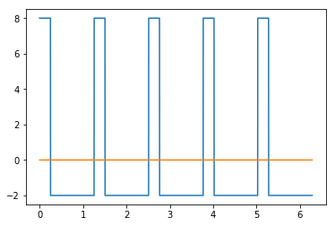

```python
Vac=v-Vmed
plt.plot(t,Vac,t,np.zeros(len(t)))
print("El valor medio despues del capacitor es = {} V".format(np.mean(Vac)))
```

Luego del acople capacitivo, el instrumento en alterna tiene un puente rectificador que transforma a la señal en continua

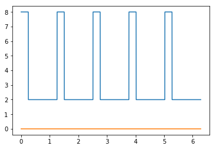

```python
Vrect=np.abs(Vac)
plt.plot(t,Vrect,t,np.zeros(len(t)))
```

## Instrumento que responde a valor medio de modulo

Estos intrumento tienen un detector de valor medio

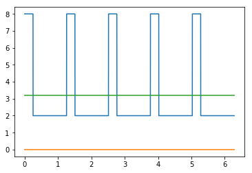

```python
Vmed_mod=np.mean(Vrect)
Vmed_mod=np.full(len(t),Vmed_mod)
plt.plot(t,Vrect,t,np.zeros(len(t)),t,Vmed_mod)
```

Luego que el detector entrega en nivel de DC igual al valor caracteristico detectado, el multimetro multiplica por la constante de calibración correspondiente. Para valor medio de módulo es 1,11 para finalmente mostrarlo en pantalla

[figure not shown]

```python
Kme=np.pi/(2*np.sqrt(2))
Vi=Vmed_mod[1]*Kme
print("mostrado en pantalla es {} V".format(Vi))
```

```
mostrado en pantalla es 3.554306350526693 V
```

# Como corregir la lectura para hallar el valor deseado

Aunque hay algunos instrumentos que dan la opcion DC+AC, Lo que esperamos medir cuando ponemos un multímetro en alterna es el valor eficaz de la componente de alterna (AC). Además sabemos que en AC hay acople capacitivo, de la misma manera que en el vertical de un osciloscopio.

```
VRMS_AC = 4.0 V
```

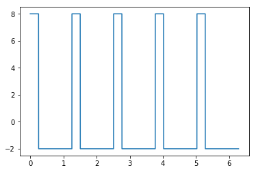

```python
plt.plot(t,Vac)
VRMS_AC=np.sqrt(np.mean(Vac**2))
print("VRMS_AC = {} V".format(VRMS_AC))
```

$$ VRMS={ \sqrt{VAC^2+VDC^2}}$$

```python
print("VRMS AC+DC = {} V".format((VRMS_AC**2+Vmed**2)**0.5))
```

```
VRMS AC+DC = 4.47213595499958 V
```

[figure not shown]

```python
RMS_corregido=(np.sqrt(2)/(np.pi*np.sqrt(d*(1-d))))*Vi
print(" Valor corregido = {} V".format(RMS_corregido))
```

```
 Valor corregido = 4.0 V
```

## Conclusiones

#### Podemos calcular valores eficaces de manera directa

#### Podemos simular el comportamiento del instrumento

#### Conociendo el comportamiento del instrumento podemos hallar el valor deseado